# Analysis of Sleep Factors Utilizing Fitbit Data Tracking

08/19/2024

# Background: Analyzing Sleep Quality from Produced Fitbit Data

Data sourced from: https://www.kaggle.com/datasets/arashnic/fitbit/data

# Background: Notice of Dataset Downsides

Note: The reliability of this dataset does have some concerns that must be noted for the sake of further analysis

- Demographic: Not available in the dataset, it is entirely anonymized and persons are assigned ID numbers alone
- Age : Not available
- Personal Information (conditions, and similar factors): Not present, and as such the data is presented generally without external factors that may have influenced odd sections of data.

# Pulling Important Libraries

```r
#General functions that will be useful in formatting, processing, and cleaning the data
library (tidyverse)
```

```r
library(lubridate) # Processes Dates
library (ggplot2) # Produces Plots
library(gridExtra) # Formats Plots on Slide-Deck
```

# Subsetting Data From the Dataset to Analyze Groups

```r
# Pulls Data from the github page, the csv files below are the only remaining datasets in the fitbit data for the sake of storage size

# Pulling several CSV files from the folder to create a consolidated dataframe after having matching groups / user data to compare
sleepMinutes <- read.csv("https://raw.githubusercontent.com/VilcekSummerR/final-assignment-JustinVeerasami/main/FitBItData/mturkfitbit_export_4.12.16-5.12.16/Fitabase%20Data%204.12.16-5.12.16/minuteSleep_merged.csv?token=GHSAT0AAAAAACUS4QMRH65DLWN4MI7BOWNOZV6SANA")
sleepMinutes <- sleepMinutes[,1:3]

# Data containing Intensity levels, Calories burned, Steps, etc.
dailyActivity <- read.csv("https://raw.githubusercontent.com/VilcekSummerR/final-assignment-JustinVeerasami/main/FitBItData/mturkfitbit_export_4.12.16-5.12.16/Fitabase%20Data%204.12.16-5.12.16/dailyActivity_merged.csv?token=GHSAT0AAAAAACUS4QMQT7NCLLF3UUTAVRCQZV6SAGA")

# Data containing MET (metabolic) values (raw data multiplies proper amount by x10)
dailyMET <- read.csv("https://raw.githubusercontent.com/VilcekSummerR/final-assignment-JustinVeerasami/main/FitBItData/mturkfitbit_export_4.12.16-5.12.16/Fitabase%20Data%204.12.16-5.12.16/METDailyData.csv?token=GHSAT0AAAAAACUS4QMRGRA7VU7XROTTK5JCZV6R75Q")
dailyMET <- dailyMET[2:8]

# Data regarding sleep days, time spent sleeping and time in bed
sleepDay <- read.csv("https://raw.githubusercontent.com/VilcekSummerR/final-assignment-JustinVeerasami/main/FitBItData/mturkfitbit_export_4.12.16-5.12.16/Fitabase%20Data%204.12.16-5.12.16/sleepDay_merged.csv?token=GHSAT0AAAAAACUS4QMQIBE2PUGZQ2HQ3XL4ZV6SATA")
```

IMPORTANT NOTE: MET DATA IS PRESUBSET FROM THE ORIGINAL DATA IN ORDER TO ADD TO GITHUB FOR EASE OF ACCESS.

- The data was essentially consolidated into daily chunks so the minute data wouldn’t overload the storage requirements as seen below.
- The functions below were used to process the minuteMETSNarrow_merged data from the kaggle dataset to make it usable in the repository.

```r
# For the sake of reproducibility, steps taken to format the data prior to adding it as the datasource on github are shown below. The hashtags may be removed to use it as workable code to format the MET data.

#library(tidyverse)

## Assuming Working Directory is located on a folder stored in the desktop
#setwd("C:/Users/Ram Veerasami/Desktop/FitBitData/mturkfitbit_export_4.12.16-5.12.16/Fitabase Data 4.12.16-5.12.16/")

## Data containing MET (metabolic) values (raw data multiplies proper amount by x10)
#minuteMET <- read.csv("minuteMETsNarrow_merged.csv")
#dailyMET <- minuteMET

#names(dailyMET)[2] <- "date"

## Grouping methods that pull the mean, median, min, max, and range of the MET values for each day per user ID.
#dailyMETConsolidated <- dailyMET %>% group_by(Id, as.Date(date, format = "%m/%d/%Y")) %>% summarise(METMean = mean(METs, na.rm = TRUE))

#dailyMETConsolidated$METMedian <- dailyMET %>% group_by(Id, as.Date(date, format = "%m/%d/%Y")) %>% summarise(METMedian = median(METs, na.rm = TRUE)) %>% ungroup() %>% pull(METMedian)

#dailyMETConsolidated$METMin <- dailyMET %>% group_by(Id, as.Date(date, format = "%m/%d/%Y")) %>% summarise(METMin = min(METs, na.rm = TRUE)) %>% ungroup() %>% pull(METMin)

#dailyMETConsolidated$METMax <- dailyMET %>% group_by(Id, as.Date(date, format = "%m/%d/%Y")) %>% summarise(METMax = max(METs, na.rm = TRUE)) %>% ungroup() %>% pull(METMax)

#dailyMETConsolidated$METRange <- (dailyMETConsolidated$METMax - dailyMETConsolidated$METMin)

## renames the column as there was some small issue that caused a rename of the date column
#names(dailyMETConsolidated)[2] <- "Date"

## saves it as a much smaller csv to work with in main project assuming working directory is the original folder for 4.12.16-5.12.16
## Note date is stored as YYYY-MM-DD so it has a separate formatting for data calculations which is done later in this project
#write.csv(dailyMETConsolidated,"METDailyData.csv")
```

# Methods: Initial Data Overview

Establishing a Dataframe Heirarchy: Allows the left join process later in the project to function without any gaps in data

```r
#quickly showing an overview of the datasets to obtain ID's shared between all dataframes. The dataframe with the lowest IDNum will be used as the reference to pull other data to consolidate information regarding the sleep data

chosenData <- c("sleepMinutes", "dailyActivity", "dailyMET", "sleepDay")
IDNum <- c(n_distinct(sleepMinutes$Id), n_distinct(dailyActivity$Id), n_distinct(dailyMET$Id), n_distinct(sleepDay$Id))

data.frame(chosenData, IDNum)
```

```
##      chosenData IDNum
## 1  sleepMinutes    24
## 2 dailyActivity    33
## 3      dailyMET    33
## 4      sleepDay    24
```

# Methods: Main Dataset Cleaning

```r
# Removes duplicates and NA values
sleepMinutes <- sleepMinutes %>% distinct() %>% drop_na()
dailyActivity <- dailyActivity %>% distinct() %>% drop_na()
dailyMET <- dailyMET %>% distinct() %>% drop_na()
sleepDay <- sleepDay %>% distinct() %>% drop_na()

# Re-checks to ensure the ID's dont get messed up from the initial dataframe
chosenData <- c("sleepMinutes", "dailyActivity", "dailyMET", "sleepDay")
IDNum <- c(n_distinct(sleepMinutes$Id), n_distinct(dailyActivity$Id), n_distinct(dailyMET$Id), n_distinct(sleepDay$Id))

data.frame(chosenData, IDNum)
```

```
##      chosenData IDNum
## 1  sleepMinutes    24
## 2 dailyActivity    33
## 3      dailyMET    33
## 4      sleepDay    24
```

# Methods: Data Recoding

```r
# recoding sleepMinutes to fit the fitbit defined dictionary handbook
sleepMinutes <- sleepMinutes %>% mutate(SleepStatus = recode_factor(value, '1' = "Asleep", '2' = "Restless", '3' = "Awake"))
sleepMinutes <- sleepMinutes[,-3]
```

Data Consolidation of Sleep Information (Minutes to Entire Day Values to condense data to fit other daily criteria)

```r
sleepConsolidate <- sleepMinutes

sleepSummary <- sleepConsolidate %>% group_by(Id, as.Date(date, format = "%m/%d/%Y")) %>% summarise(Awake = sum(SleepStatus == "Awake", na.rm = TRUE), Restless = sum(SleepStatus == "Restless", na.rm = TRUE), Asleep = sum(SleepStatus == "Asleep", na.rm = TRUE))

names(sleepSummary)[2] <- "Date"

#cleans away older data from Rstudio
rm(sleepConsolidate,sleepMinutes)

head(sleepSummary)
```

```
## # A tibble: 6 × 5
## # Groups:   Id [1]
##           Id Date       Awake Restless Asleep
##        <dbl> <date>     <int>    <int>  <int>
## 1 1503960366 2016-04-12     6       13    327
## 2 1503960366 2016-04-13    12       11    384
## 3 1503960366 2016-04-15     8       22    412
## 4 1503960366 2016-04-16     8       20    372
## 5 1503960366 2016-04-17     0       11    668
## 6 1503960366 2016-04-19     0       16    304
```

# Methods: Further consolidation of initial minute_Sleep data to that of the sleepDay data for daily parameters in full detail

```r
sleepDay <- sleepDay %>% rename(Date = SleepDay) %>% mutate(Date=as.Date(Date, format="%m/%d/%Y"))

# Joins all of the formatted sleepMinutes and sleepDay data. sleepSummary was chosen as the left factor to further check the NA values and why they show up.
sleepDataDaily <- left_join(sleepSummary,sleepDay,by = c('Id','Date'))

# Cleans out Asleep Times <30 minutes as such a parameter falls closer into a category of napping as per:sleepfoundation.org
# https://www.sleepfoundation.org/napping#:~:text=Longer%20naps%2C%20such%20as%20those,woken%20up%20during%20deep%20sleep.
sleepDataDaily <- sleepDataDaily[sleepDataDaily$Asleep >= 30, ]

#cleans away sleepDay
rm(sleepDay,sleepSummary)

head(sleepDataDaily)
```

```
## # A tibble: 6 × 8
## # Groups:   Id [1]
##         Id Date       Awake Restless Asleep TotalSleepRecords TotalMinutesAsleep
##      <dbl> <date>     <int>    <int>  <int>             <int>              <int>
## 1   1.50e9 2016-04-12     6       13    327                 1                327
## 2   1.50e9 2016-04-13    12       11    384                 2                384
## 3   1.50e9 2016-04-15     8       22    412                 1                412
## 4   1.50e9 2016-04-16     8       20    372                 2                340
## 5   1.50e9 2016-04-17     0       11    668                 1                700
## 6   1.50e9 2016-04-19     0       16    304                 1                304
## # ℹ 1 more variable: TotalTimeInBed <int>
```

Viewing NA values in the consolidated list

```r
# Display rows where 'TotalSleepRecords' has NA values
na_sleeprows <- sleepDataDaily[is.na(sleepDataDaily$TotalSleepRecords), ]

# Viewing the dataset to see if these values will be omit or reclassified before further cleaning
head(na_sleeprows)
```

```
## # A tibble: 6 × 8
## # Groups:   Id [3]
##         Id Date       Awake Restless Asleep TotalSleepRecords TotalMinutesAsleep
##      <dbl> <date>     <int>    <int>  <int>             <int>              <int>
## 1   1.64e9 2016-05-01   129       36    194                NA                 NA
## 2   1.93e9 2016-04-11     0        0    124                NA                 NA
## 3   1.93e9 2016-04-14     0        4     47                NA                 NA
## 4   1.93e9 2016-04-25     0       10    115                NA                 NA
## 5   2.03e9 2016-04-11     1       29    162                NA                 NA
## 6   2.03e9 2016-04-18     4       23    169                NA                 NA
## # ℹ 1 more variable: TotalTimeInBed <int>
```

# Methods: Reclassifying NA values of na_sleeprows to allow dataset to be usable in future calculations / graphs

```r
na_sleeprows$TotalSleepRecords <- 1 #counts the sleep records as valid events

na_sleeprows <- na_sleeprows[c(1:6)]
na_sleeprows$TotalMinutesAsleep <- na_sleeprows$Asleep
na_sleeprows$TotalTimeInBed <- (na_sleeprows$Asleep + na_sleeprows$Restless + na_sleeprows$Awake)
```

Formatting the main dataset so that it allows all of the formatted NA values to be input as valid data values

```r
# After formatting NA rows to be usable data, replace the NA values with their reformatted values using the ID / Date relationship
sleepDataDaily <- sleepDataDaily %>% rows_update(na_sleeprows, by = c("Id", "Date"))

# Verify the NA values have been replaced
na_sleeprows <- sleepDataDaily[is.na(sleepDataDaily$TotalSleepRecords), ]
head(na_sleeprows)
```

```
## # A tibble: 0 × 8
## # Groups:   Id [0]
## # ℹ 8 variables: Id <dbl>, Date <date>, Awake <int>, Restless <int>,
## #   Asleep <int>, TotalSleepRecords <int>, TotalMinutesAsleep <int>,
## #   TotalTimeInBed <int>
```

Resulting Sleep Dataset Consolidated

```r
# cleans previous NA sleeprows from environment
rm(na_sleeprows)

# Assuring the total minutes asleep and time in bed math were not done improperly
sleepDataDaily$TotalMinutesAsleep <- sleepDataDaily$Asleep
sleepDataDaily$TotalTimeInBed <- (sleepDataDaily$Asleep + sleepDataDaily$Restless + sleepDataDaily$Awake)

head(sleepDataDaily)
```

```
## # A tibble: 6 × 8
## # Groups:   Id [1]
##         Id Date       Awake Restless Asleep TotalSleepRecords TotalMinutesAsleep
##      <dbl> <date>     <int>    <int>  <int>             <int>              <int>
## 1   1.50e9 2016-04-12     6       13    327                 1                327
## 2   1.50e9 2016-04-13    12       11    384                 2                384
## 3   1.50e9 2016-04-15     8       22    412                 1                412
## 4   1.50e9 2016-04-16     8       20    372                 2                372
## 5   1.50e9 2016-04-17     0       11    668                 1                668
## 6   1.50e9 2016-04-19     0       16    304                 1                304
## # ℹ 1 more variable: TotalTimeInBed <int>
```

# Methods: Creating Definitions for Sleep Quality

Basic General Definition

```r
# Formatting a sleep score so that quality of sleep is built off of total sleep time in a day (Uses recommended amt of total sleep and has a buffer of the deviation range mentioned in the paper above)
sleepDataDaily$SleepScoreCategory <- ifelse((sleepDataDaily$TotalMinutesAsleep %/% 60 >= 7) & (sleepDataDaily$TotalMinutesAsleep %/% 60 <= 9), "Good Sleep",ifelse((sleepDataDaily$TotalMinutesAsleep %/% 60 >= 6.5) & (sleepDataDaily$TotalMinutesAsleep %/% 60 < 7) |(sleepDataDaily$TotalMinutesAsleep %/% 60 > 9) & (sleepDataDaily$TotalMinutesAsleep %/% 60 <= 10.5),"Decent Sleep","Poor Sleep"))


# Setting a column for efficiency pertaining to amount of sleep undisturbed
sleepDataDaily$SleepEfficiencyScore <- (sleepDataDaily$TotalMinutesAsleep / sleepDataDaily$TotalTimeInBed)
```

# Methods: Creation of the Final Dataframe

```r
# In this section perform a left join of daily activity and the sleepDataDaily with daily activities on the left. Clean out NA values afterwards to have sleep scores related to the daily activity data. The same will be done for dailyMET to have the metabolic data added

# Reformatting date values in dailyActivity to ensure join has no errors
dailyActivity <- dailyActivity %>% rename(Date = ActivityDate) %>% mutate(Date=as.Date(Date, format="%m/%d/%Y"))

dailyActivityvSleep <- left_join(dailyActivity,sleepDataDaily,by = c('Id','Date'))

dailyActivityvSleep <- drop_na(dailyActivityvSleep)

rm(dailyActivity)
```

Performing a Left Join on Metabolic Data

```r
dailyMET <- dailyMET %>% mutate(Date=as.Date(Date, format="%Y-%m-%d"))

dailyActivityvSleep <- left_join(dailyActivityvSleep,dailyMET,by = c('Id','Date'))

dailyActivityvSleep <- drop_na(dailyActivityvSleep, SleepScoreCategory)

sleepData <- dailyActivityvSleep

# Cleans the remaining data
rm(dailyMET, sleepDataDaily, dailyActivityvSleep)


head(sleepData)
```

```
##           Id       Date TotalSteps TotalDistance TrackerDistance
## 1 1503960366 2016-04-12      13162          8.50            8.50
## 2 1503960366 2016-04-13      10735          6.97            6.97
## 3 1503960366 2016-04-15       9762          6.28            6.28
## 4 1503960366 2016-04-16      12669          8.16            8.16
## 5 1503960366 2016-04-17       9705          6.48            6.48
## 6 1503960366 2016-04-19      15506          9.88            9.88
##   LoggedActivitiesDistance VeryActiveDistance ModeratelyActiveDistance
## 1                        0               1.88                     0.55
## 2                        0               1.57                     0.69
## 3                        0               2.14                     1.26
## 4                        0               2.71                     0.41
## 5                        0               3.19                     0.78
## 6                        0               3.53                     1.32
##   LightActiveDistance SedentaryActiveDistance VeryActiveMinutes
```

[output cut: 34 more lines]

# Results: Initial Analysis in relation to Daily Parameters

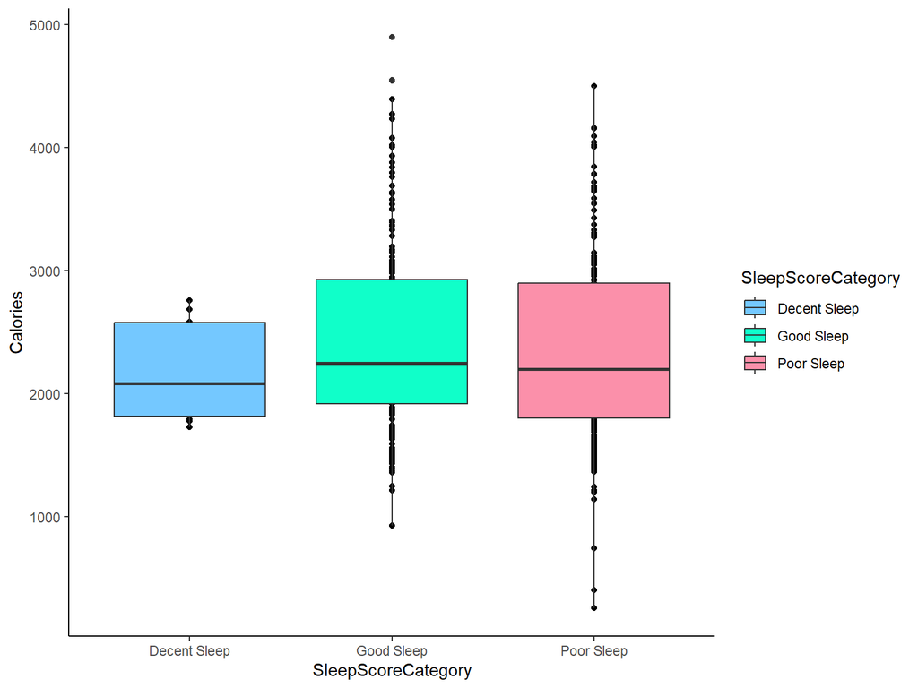

```r
SleepCategoryColor <- c("Decent Sleep" = "#74c8ff","Good Sleep" = "#10ffc9","Poor Sleep" = "#fb90aa")

ggplot(sleepData, aes(x=SleepScoreCategory, y=Calories, fill = SleepScoreCategory)) + geom_point() + geom_boxplot()+ scale_fill_manual(values = SleepCategoryColor)+theme_classic()
```

The spread of daily calories seem to describe a rather insignificant relationship between the calories burned per day and sleep scores

- Notably, the poor sleep and good sleep categories have very similar distributions based off their medians / quartiles indicating calories burned alone do not seem to have a major influence

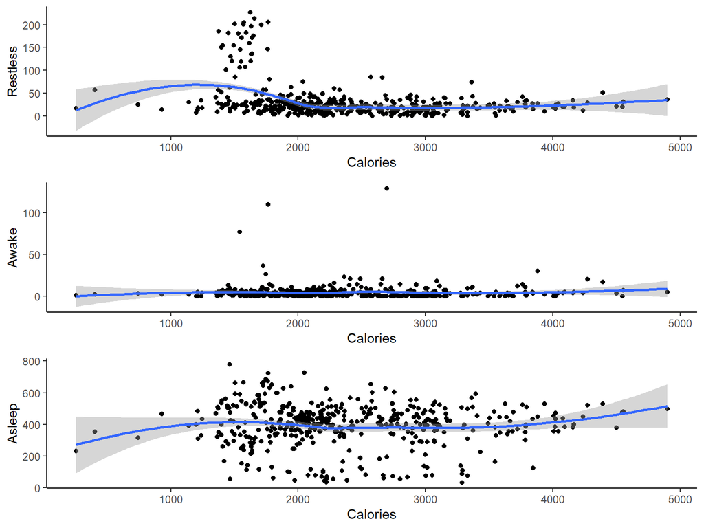

```r
# possible relation of low daily calories and increased restlessness seen with notable outliers
c1 <- ggplot(sleepData, aes(x=Calories, y=Restless)) + geom_point() + geom_smooth()+theme_classic()
c2 <- ggplot(sleepData, aes(x=Calories, y=Awake)) + geom_point() + geom_smooth()+theme_classic()
c3 <- ggplot(sleepData, aes(x=Calories, y=Asleep)) + geom_point() + geom_smooth()+theme_classic()

grid.arrange(c1, c2, c3,ncol=1, nrow=3)
```

There does seem to be a potential relation of low daily calories in relation to increased restlessness seen with notable outliers in the first graph below. The total calories seem to not have any correlation to increases in awake / asleep statuses.

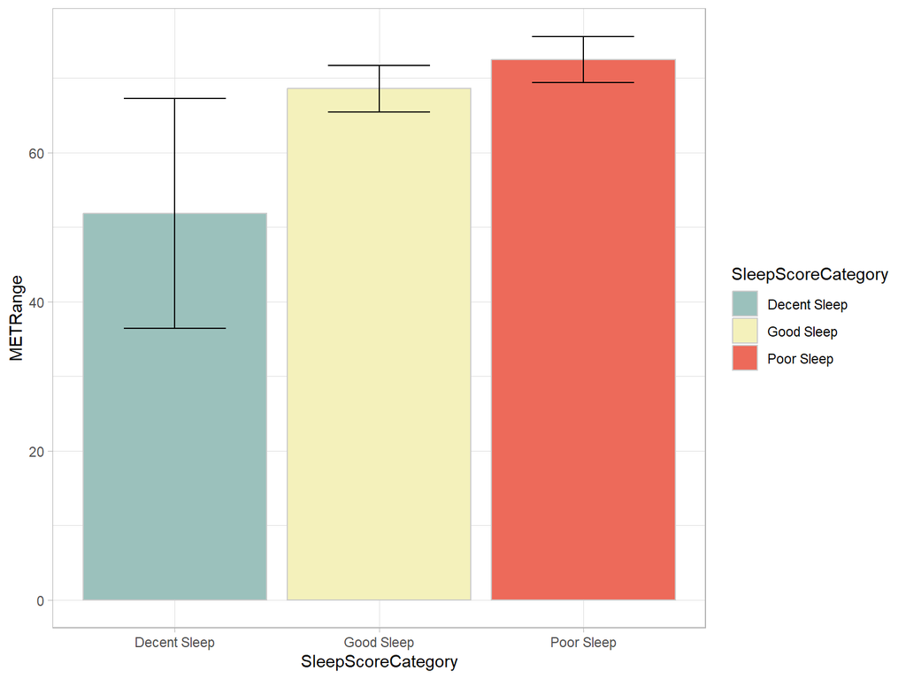

```r
SleepCategoryColor <- c("Decent Sleep" = "#9bc1bc","Good Sleep" = "#f4f1bb","Poor Sleep" = "#ed6a5a")

# Analysis of Metabolic Range and Sleep Categories
ggplot(sleepData, aes(x=SleepScoreCategory, y=METRange)) + stat_summary(fun = mean, geom="bar",aes(fill = SleepScoreCategory),color="grey80")+ scale_fill_manual(values = SleepCategoryColor)+ stat_summary(fun.data = mean_cl_normal, geom = "errorbar", width = .5) +theme_light()
```

Using metabolic range as an indicator of highs versus lows of physical activity in the day, there does seem to be small differences between the sleep categories. That being said, with the error bars in mind, these differences do not seem to be as significant due to considerable overlaps of margins of error.

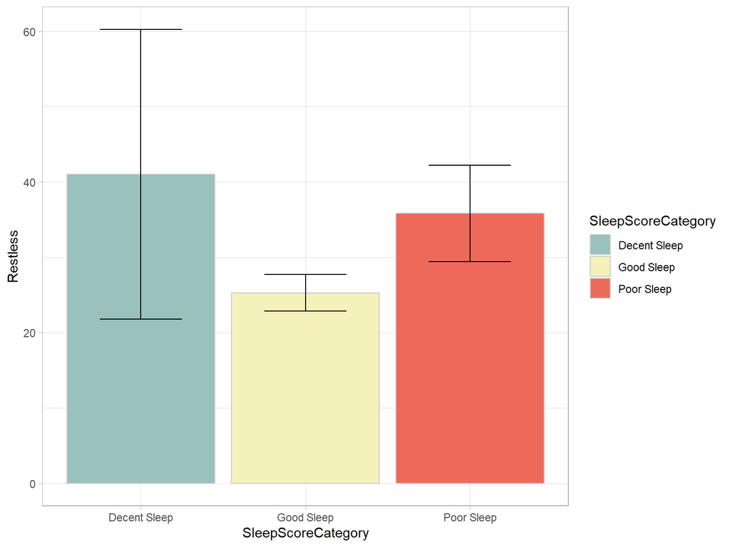

```r
# There seems to be a present relationship of the sleep score to that of the restless minutes between the good and bad sleep
ggplot(sleepData, aes(x=SleepScoreCategory, y=Restless)) + stat_summary(fun = mean, geom="bar",aes(fill = SleepScoreCategory),color="grey80")+ scale_fill_manual(values = SleepCategoryColor)+ stat_summary(fun.data = mean_cl_normal, geom = "errorbar", width = .5) +theme_light()
```

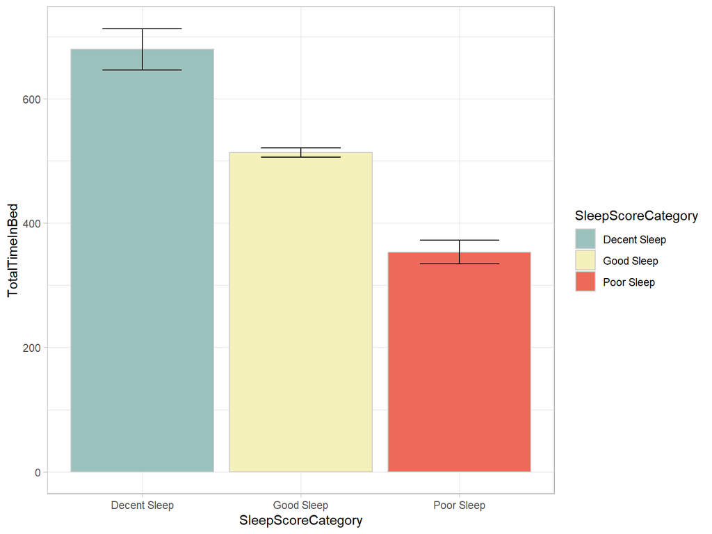

```r
# Poor Sleep was usually indicative of less hours in bed rather than surpassing the oversleep criteria
ggplot(sleepData, aes(x=SleepScoreCategory, y=TotalTimeInBed))+ stat_summary(fun = mean, geom="bar",aes(fill = SleepScoreCategory),color="grey80")+ scale_fill_manual(values = SleepCategoryColor)+ stat_summary(fun.data = mean_cl_normal, geom = "errorbar", width = .5) +theme_light()
```

As an overview of the true time spent in bed, good sleep shows a clear gap from the poor sleep category. This is not as significant due to the classification involved in making the groups.

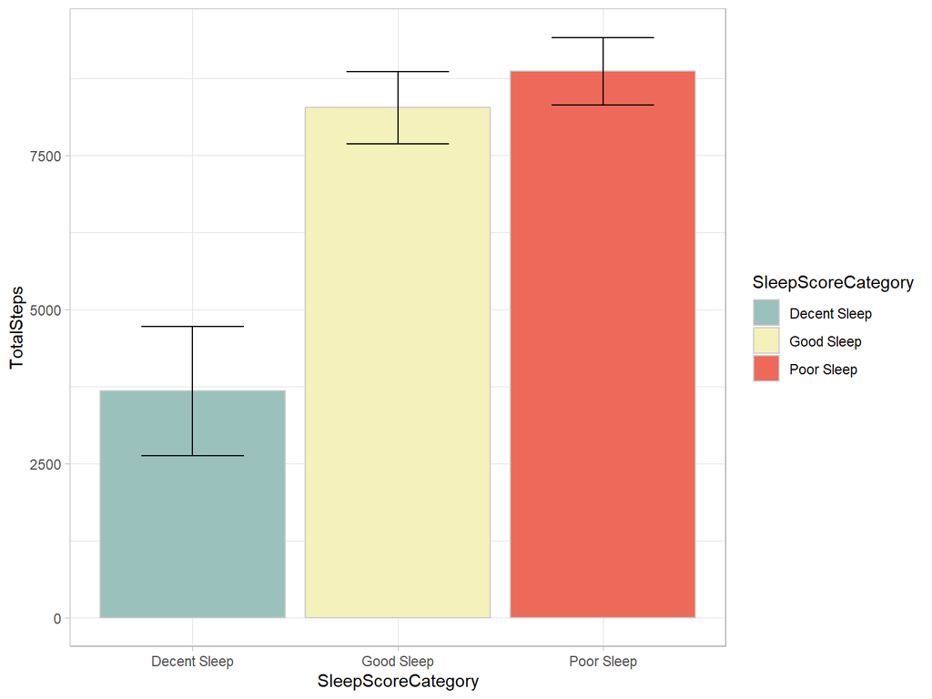

```r
# Surprisingly decent sleep falls sharply off the total steps of the good / bad sleep groups
ggplot(sleepData, aes(x=SleepScoreCategory, y=TotalSteps))+ stat_summary(fun = mean, geom="bar",aes(fill = SleepScoreCategory),color="grey80")+ scale_fill_manual(values = SleepCategoryColor)+ stat_summary(fun.data = mean_cl_normal, geom = "errorbar", width = .5) +theme_light()
```

Of this plot, the most major datapoint exists in decent sleep where there is a very sharp drop in total steps for decent sleep versus the good/poor categories.

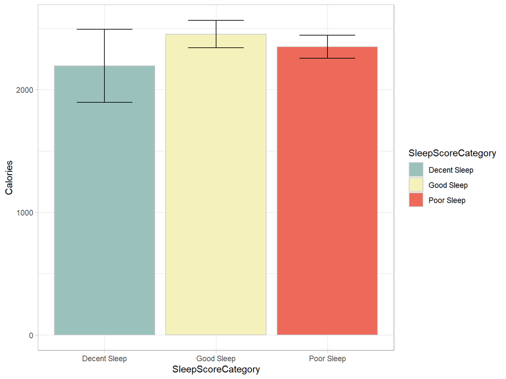

```r
ggplot(sleepData, aes(x=SleepScoreCategory, y=Calories))+ stat_summary(fun = mean, geom="bar",aes(fill = SleepScoreCategory),color="grey80")+ scale_fill_manual(values = SleepCategoryColor)+ stat_summary(fun.data = mean_cl_normal, geom = "errorbar", width = .5) +theme_light()
```

Good sleep shows a slightly higher caloric burn rate, but the differences between the groups are not significant enough to warrant any further analysis due to their overlaps.

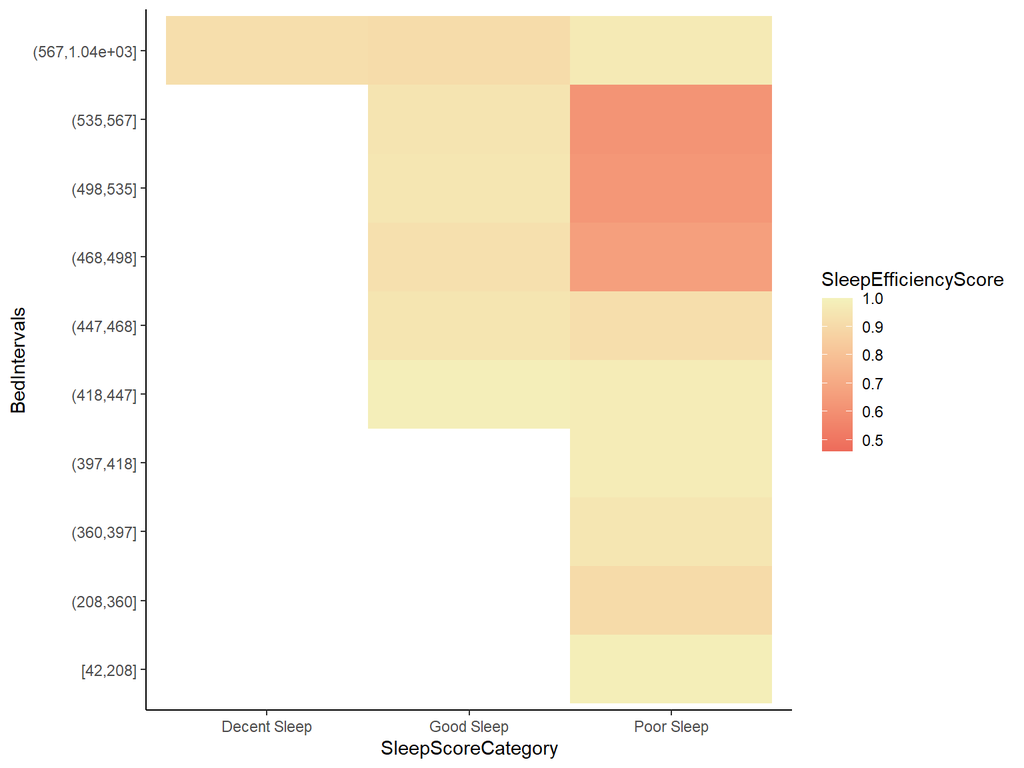

```r
# Trying to categorize data to use intervals (2 sets of categorical data) for testing via a heatmap
sleepDataIntervalTesting <- sleepData %>%mutate(BedIntervals = cut_number(TotalTimeInBed, n=10))

# A heatmap of what notably seems to be a struggle time interval for those with poor sleep where their sleep efficiency plummets around the 468-567 minute group
ggplot(sleepDataIntervalTesting, aes(x=SleepScoreCategory, y=BedIntervals, fill=SleepEfficiencyScore))+ geom_tile() + scale_fill_gradient(low= "#ed6a5a",high="#f4f1bb")+theme_classic()
```

Bed time intervals were mapped out in relation to their sleep categories to see how efficient these intervals were in sleep. What came as a initial surprise was the odd gap of time with a sharp drop in sleep efficiency for the poor sleep group. Such was a group that I would definitely hope to further analyze later into this project.

# Results: Analysis of Daily Activity Minutes Broken Down

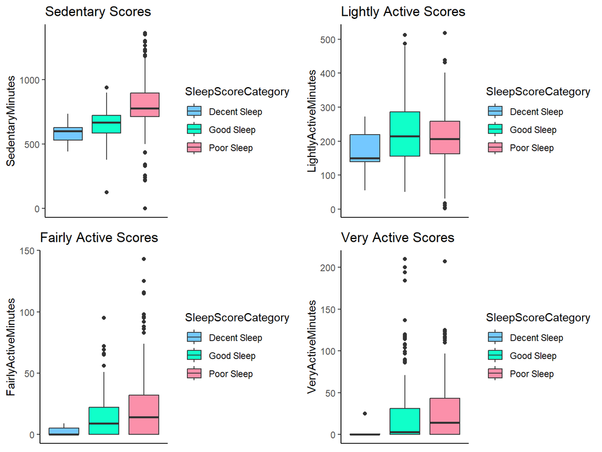

```r
# Creating a boxplots of minutes of activity in relation to sleep score categories
sleepVSActiveMinutes <- sleepData[c(11:14,22)]

# Assigning a color scheme for the categories for ease of viewing
SleepCategoryColor <- c("Decent Sleep" = "#74c8ff","Good Sleep" = "#10ffc9","Poor Sleep" = "#fb90aa")

# Setting up separate boxplots to arrange in a grid format to see the side by side of the sleep categories and activity minutes
p1 <- ggplot(sleepVSActiveMinutes,aes(x=SleepScoreCategory,y=SedentaryMinutes, fill=SleepScoreCategory))+geom_boxplot()+ scale_fill_manual(values = SleepCategoryColor)+theme_classic()+theme(axis.text.x=element_blank(), axis.ticks.x=element_blank()) + ggtitle("Sedentary Scores") + labs(x=NULL)

p2 <- ggplot(sleepVSActiveMinutes,aes(x=SleepScoreCategory,y=LightlyActiveMinutes, fill=SleepScoreCategory))+geom_boxplot()+ scale_fill_manual(values = SleepCategoryColor)+theme_classic()+theme(axis.text.x=element_blank(), axis.ticks.x=element_blank())+ ggtitle("Lightly Active Scores")+ labs(x=NULL)

p3 <- ggplot(sleepVSActiveMinutes,aes(x=SleepScoreCategory,y=FairlyActiveMinutes, fill=SleepScoreCategory))+geom_boxplot()+ scale_fill_manual(values = SleepCategoryColor)+theme_classic()+theme(axis.text.x=element_blank(), axis.ticks.x=element_blank())+ ggtitle("Fairly Active Scores")+ labs(x=NULL)

p4 <- ggplot(sleepVSActiveMinutes,aes(x=SleepScoreCategory,y=VeryActiveMinutes, fill=SleepScoreCategory))+geom_boxplot()+ scale_fill_manual(values = SleepCategoryColor)+theme_classic()+theme(axis.text.x=element_blank(), axis.ticks.x=element_blank())+ ggtitle("Very Active Scores")+ labs(x=NULL)

grid.arrange(p1, p2, p3, p4, ncol=2, nrow=2)
```

As a brief breakdown of daily activity efforts in relation to their sleep score influence, there does seem to be the most relevancy regarding the sedentary scores portion of this chart interface. The box plots seem to have reasonable spacing indicative of data differences that may influence the effects on sleep to a larger degree where perhaps more sedentary behavior may correspond to a lower sleep quality.

# Discussion: Further Analysis of Notable Results

Having taken a look at notable sections I wanted to analyze in order to see if several daily activities had a major effect on sleep factors, I decided on analyzing the following variables for this project to see if their results were significant and statistically relevant:

- **Sleep Score Categories, Bed Time Intervals, and their efficiency score**
- **Total steps in relation to their sleep scores**

These points were chosen due to factors of curiosity on my end with how they interact with the data and also the factors of how initially significant they looked upon doing a very brief overview of the graphs generated by the dataframe. While there were other variables that I wanted to analyze, I chose these two variables due to the factors before and the sake of timing with the scope of this project.

# Discussion: Analysis of Total Steps Versus Sleep Scores

[figure not shown]

```r
kruskal.test(sleepDataIntervalTesting$TotalSteps ~ sleepDataIntervalTesting$SleepScoreCategory)
```

```
##
##  Kruskal-Wallis rank sum test
##
## data:  sleepDataIntervalTesting$TotalSteps by sleepDataIntervalTesting$SleepScoreCategory
## Kruskal-Wallis chi-squared = 16.925, df = 2, p-value = 0.0002113
```

As an initial test of group significance, a kruskal test indicates a potentially significant difference between the categories of sleep and their total steps taken daily. This aids in the potential assumption that the sleep categories do have factors either affecting the total steps being used through the day or instead being affected by total steps taken prior to sleep.

```r
sleepDataIntervalTesting$StepDichotomy <- ifelse(sleepDataIntervalTesting$SleepScoreCategory == "Good Sleep" | sleepDataIntervalTesting$SleepScoreCategory == "Poor Sleep", "Regular Steps", "Lower Steps")

wilcox.test( sleepDataIntervalTesting$TotalSteps ~ sleepDataIntervalTesting$StepDichotomy)
```

```
##
##  Wilcoxon rank sum test with continuity correction
##
## data:  sleepDataIntervalTesting$TotalSteps by sleepDataIntervalTesting$StepDichotomy
## W = 636, p-value = 0.0001519
## alternative hypothesis: true location shift is not equal to 0
```

Further dichotomization was done to consolidate the good/poor sleep versus the decent sleep to see how the steps truly varies between the two groups. Using a wilcox test, data indicates that there is a significant shift as earlier with the decent sleep category and the other sleep categories where the p-value of 0.0001519 seems to fall under the required threshold.

- To further characterize the data, a t-test will be done with an assumption of normality.

```r
# Assuming normal distribution which acts as more of a stretch on the data as it does seem to deviate from normality after 2 deviations.
t.test( sleepDataIntervalTesting$TotalSteps ~ sleepDataIntervalTesting$StepDichotomy)
```

```
##
##  Welch Two Sample t-test
##
## data:  sleepDataIntervalTesting$TotalSteps by sleepDataIntervalTesting$StepDichotomy
## t = -9.7583, df = 12.799, p-value = 2.724e-07
## alternative hypothesis: true difference in means between group Lower Steps and group Regular Steps is not equal to 0
## 95 percent confidence interval:
##  -6027.994 -3839.884
## sample estimates:
##   mean in group Lower Steps mean in group Regular Steps
##                    3675.200                    8609.139
```

With the loose assumption of normality as the data slightly skews off after 2 deviations, there is a significant gap shown between the lower step group (decent sleep) versus the regular steps (good and poor sleep) with the means being nearly 5000 steps off.

- As a major note however, upon viewing the decent sleep category in detail there was noted to be 10 actual units involved with decent sleep in the dataframe. This limited sum of cells compared to the rest of the dataset could also be indicative of further testing having to be done to verify such a result

# Discussion: Further Analysis of Sleep Efficiency and Time Spent in Bed

[figure not shown]

Running a Spearman Rho Test to see the correlation of the sleep efficiencies and Total Time in Bed

```r
cor.test(sleepDataIntervalTesting$SleepEfficiencyScore,sleepDataIntervalTesting$TotalTimeInBed, method = "spearman")
```

```
##
##  Spearman's rank correlation rho
##
## data:  sleepDataIntervalTesting$SleepEfficiencyScore and sleepDataIntervalTesting$TotalTimeInBed
## S = 13119317, p-value = 0.3633
## alternative hypothesis: true rho is not equal to 0
## sample estimates:
##        rho
## 0.04369374
```

The p-value of 0.3633 indicates that there is not as strong of a correlation of the sleep efficiency in relation to the time spent in bed. The number is quite high and above a standard number of say, 0.05

```r
# Attempting to shave off the total time in bed section to fit the notable section

isolatedIntervalData <- sleepData[sleepData$TotalTimeInBed >= 450 & sleepData$TotalTimeInBed <= 550, ]
cor.test(isolatedIntervalData$SleepEfficiencyScore,isolatedIntervalData$TotalTimeInBed, method = "spearman")
```

```
##
##  Spearman's rank correlation rho
##
## data:  isolatedIntervalData$SleepEfficiencyScore and isolatedIntervalData$TotalTimeInBed
## S = 643229, p-value = 0.6527
## alternative hypothesis: true rho is not equal to 0
## sample estimates:
##         rho
## -0.03642915
```

The p-value in this context was much higher indicating something in the data that I intended to look into to see why there was this notable section of the heatmap, but no statistical indicator (that comes to mind) for properly evaluating it.

- There was a decision to outline the section that received poor sleep in the isolated section via manual viewing

```r
sortedData <- isolatedIntervalData[c(1,16:18,20:23)]

sortedData <- sortedData[order(sortedData$SleepEfficiencyScore), ]

head(sortedData)
```

```
##             Id Awake Restless Asleep TotalMinutesAsleep TotalTimeInBed
## 95  3977333714     0      227    283                283            510
## 104 3977333714     4      201    262                262            467
## 117 3977333714     0      197    259                259            456
## 112 3977333714     8      200    292                292            500
## 91  3977333714    13      182    274                274            469
## 103 3977333714     2      214    310                310            526
##     SleepScoreCategory SleepEfficiencyScore
## 95          Poor Sleep            0.5549020
## 104         Poor Sleep            0.5610278
## 117         Poor Sleep            0.5679825
## 112         Poor Sleep            0.5840000
## 91          Poor Sleep            0.5842217
## 103         Poor Sleep            0.5893536
```

The most notable region of this data was that of the user ID: 3977333714 who in this sorted data had 17 rows of data with restless times above 100 minutes.

- Of the assumption that I could make from this analysis, I would have to say that there is a suspicion of the heatmap region receiving the lower efficiency score due to an outlier person being used within that time interval who had a large period of restlessness for each day in their categories.

```r
kruskal.test(sleepDataIntervalTesting$SleepEfficiencyScore ~ sleepDataIntervalTesting$SleepScoreCategory)
```

```
##
##  Kruskal-Wallis rank sum test
##
## data:  sleepDataIntervalTesting$SleepEfficiencyScore by sleepDataIntervalTesting$SleepScoreCategory
## Kruskal-Wallis chi-squared = 30.041, df = 2, p-value = 2.997e-07
```

As a separate result to the prior analysis though, there does seem to be a rather low p-value in the context of a Kruskal-Wallis test aimed to evaluate the 3 sleep categories produced from the data. The low p-value indicates there is a viable relationship of significant differences for sleep efficiency scores and the sleep categories.

# Conclusions

**Sleep Score Categories and Step Totals**

**Sleep Score Categories and Bed Time Intervals**

- Of the evaluations that could be done from this data. It could be noted that there were notably significant ties to the categories and their sleep efficiency scores
- While the intervals in bed themselves were not noted to experience any significant ties of data correlation, the deviance found within the heatmap could be pointed towards a significant outlier of the dataset which experienced an abnormally high amount of restless time to affect the overall sleep category.
- Such testing would be potentially remedied with an adjusted definition of the sleep categories to accomodate factors of wake time / restlessness so that outliers dont lead to abnormal group results

# Future Directions Outside of The Current Analyzed Data

Aside from the datasets analyzed in further detail within this report, there did exist other graphs with notable data that had to be skipped due to time constraints

- Examples of said data would include: (calories vs restlessness, awake time, sleep time), (sleep factors vs metabolic data (range, medians, maximums)), and (sedentary to highly active minutes versus sleep quality).
- Future research involving these datasets would follow a similar process as this project did with correlation tests to further see how other variables affect sleep factors
- Future research may also accomodate a larger, more thorough dataset to also see a detailed analysis of factors that may have lacked appropriate criteria for each section of analysis
- Finally, future research would also benefit from possibly breaking down the daily data into instead hourly data so that timeframes such as (morning, evening, and afternoon) may be classifed to see possible significant associations hidden due to holistic analysis.

# References

- Summer, J., & Summer, J. (2024, March 11). Napping: benefits and tips. Sleep Foundation. https://www.sleepfoundation.org/napping#
- Hirshkowitz, M., Whiton, K., Albert, S. M., Alessi, C., Bruni, O., DonCarlos, L., Hazen, N., Herman, J., Hillard, P. J. A., Katz, E. S., Kheirandish-Gozal, L., Neubauer, D. N., O’Donnell, A. E., Ohayon, M., Peever, J., Rawding, R., Sachdeva, R. C., Setters, B., Vitiello, M. V., & Ware, J. C. (2015). National Sleep Foundation’s updated sleep duration recommendations: final report. Sleep Health, 1(4), 233–243. https://doi.org/10.1016/j.sleh.2015.10.004